# 1. Introduction to MetaboAnalystR

## 3.3 Data normalization

```r
# Prepare object for normalization
mSet<-PreparePrenormData(mSetObj= mSet)

# Perform standard data preprocessing steps

mSet<-Normalization(mSetObj =mSet,
                    rowNorm = "NULL",
                    transNorm = "LogNorm",
                    scaleNorm = "MeanCenter",
                    ref = "S10T0", # reference sample
                    ratio=FALSE,  # only for Biomarker Analysis
                    ratioNum=20   # only for Biomarker Analysis
                    )
```

Now show normalization results. To be exact, more than “show”, plts are sent to a pdf or png file, so, if we wish them to appear in a report they must be inccluded in the markdown file.

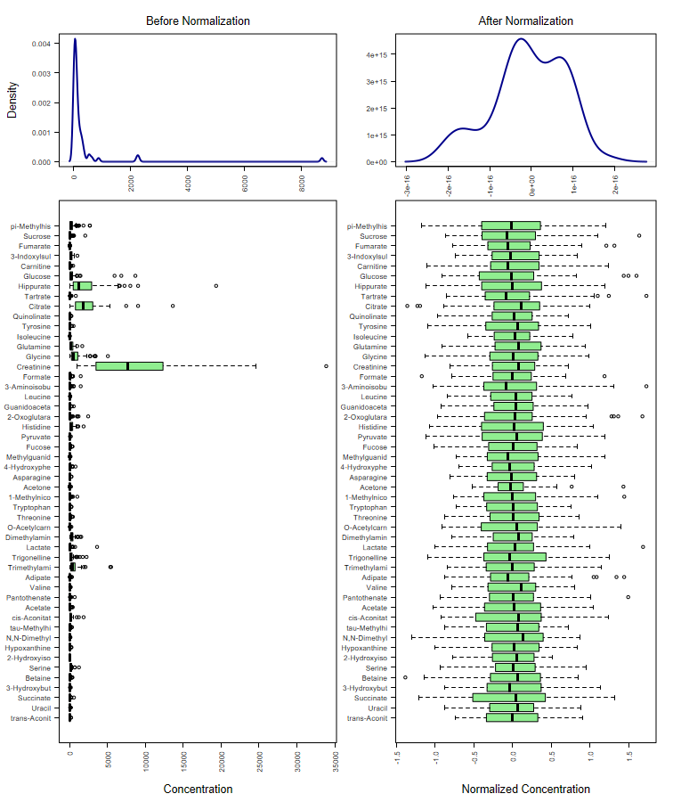

```r
# View feature normalization
mSet<-PlotNormSummary(mSet, "feature_norm", format="png", dpi=72, width=NA)
# Include recently created plot
knitr::include_graphics("feature_normdpi72.png")
```

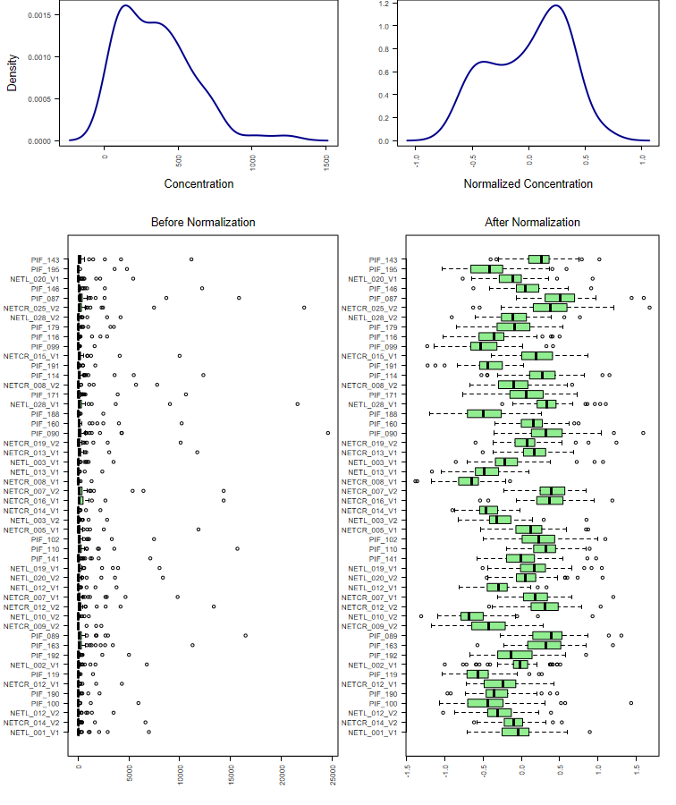

```r
# View sample normalization
mSet<-PlotSampleNormSummary(mSet, "sample_norm", format="png", width=NA)
# Include recently created plot
knitr::include_graphics("sample_normdpi72.png")
```

## 3.4 Filtering data

Data can be filtered according to distinct criteria to remove noise.

Usually we will apply only one of these.

```r
# Filter variables based on the median absolute deviation, percentage to filter out is 5 (%). No QS based filteration.
mSet <- FilterVariable(mSet, "mad", 5, "F", 25, T)
```

[output not shown]

```r
# Filter variables using Non-parametric relative standard deviation (MAD/median) and a QC-based RDS threshold is 25.
mSet <- FilterVariable(mSet, "nrsd", 5, "T", 25, T)
```

[output not shown]

## 3.5 Remove sample variables

Throughout the analysis of metabolomic data, it may be necessary to remove samples, variables, or even groups from your dataset.

Some examples of removal actions may be (not)

```r
# Remove a sample from the data set, in this case sample "PIF_178"
smpl.nm.vec <- c("PIF_178")# used to remove certain samples

# Remove a feature from the data set
feature.nm.vec <- c("2-Aminobutyrate")# used to remove certain feature, i.e. 2-Aminobutyrate

# Remove a group from the data set, in this case remove the "control" samples

grp.nm.vec <- c("control") # used to retain certain groups
```

Once the filterings or removals have been applied, update the object to remove empty slots or factor levels.

```r
mSet <- UpdateData(mSet)
```

This `mSet`object may be saved to a binary file and recovered later for further analyses without having to repeat all the process.

```r
save(mSet, file="preprocessed_Cachexia.Rda")
```